# Gene Duplications and the Evolution of Phytochrome in Early Evolving Land Plants

# Methods

Data collected for the 1KP Transcriptome project (@Leebens-Mack_2019) focusing on the phylogeny of green plants was drawn from to acquire the phytochrome sequences of mosses and the outgroup liverworts for this study. AliView was used to code the gene sequences based on amino acid sequences and nucleotide sequences. The sequences derived from ALIVIEW were then analyzed in CIPRES for any possible errors. Within CIPRES, IQ-TREE was used to generate the phylogenetic tree with specific parameters needed. The bootstrap value was set to 1000 and the number of patterns specified was 10 for both the amino acid and the nucleotide sequences. The phylogenetic tree generated was then viewed in DENDROSCAPE, which is the application needed for opening phylogenetic tree files from CIPRES and IQ-TREE. RStudio was used to generate a smaller phylogenetic tree depicting the moss lineages in relation to liverworts and hornworts. This phylogenetic tree represents the Bryophytes (Figure 1).

Figure 1. Phylogenetic tree depicting the Bryophytes linages. Hepatophyta (Liverworts) are shown to be a sister clade to Bryophyta (Mosses) and Anthocerophyta (Hornworts). Three tests were run in Datamonkey to test for selection pressures throughout the Bryophyta lineage. RELAX analysis was run using the phylogenetic tree generated from IQ-TREE. RELAX analysis were used to identify if selection was relaxed or intensified on specific lineages (@Spielman_2017). Lineages were chosen for analysis labeled as either the Reference or Test lineages. aBSREL analysis were run to find possible evidence of lineage selection (@Spielman_2017). aBSREL was used to identify any branches or segments of branches that have been subjected to positive selection (@Spielman_2017). FEL analysis was conducted, which tests for the presence of selection among different sites using the likelihood ratio test. (@Spielman_2017). This analysis estimates synonymous and nonsynonymous substitutions in the nucleotides of the mosses. Omega is a parameter used for this analysis to test for selection pressures acting on branches of the phylogenetic tree. Omega is an estimation of the nonsynonymous to synonymous substitution rates. It represents a ratio of the two (@Wertheim_2014). Omega is used to identify any deviations from the neutral omega value of omega = 1 two (@Wertheim_2014). Deviations from neutral omega explain branches / lineages subjected to positive (greater than 1) or purifying (less than 1) selection. K is a parameter that measures intensity of selection. Selection is intensified if K is grater than 1, and relaxed if K is less than 1 (@Wertheim_2014).  
R programing was used to generate Table 1. The rtree function was used in R to generate the phylogenetic trees represented in Figure 1 and Figure 4.

## Results

Table 1. Table depicts the three nodes which were found to be subjected to episodic diversifying selection. LRT (second column) lists values generated by the likelihood ratio test. P value (third column) lists values estimated from the statistical test run.

FEL The FEL analysis test was run to show if there was any evidence of selection pressure on branches of the phylogenetic tree at the codon level. The FEL analysis uses maximum likelihood ratio test to assign a model codon to each of the branch sites. (@Kosakovsky_Pond_Frost_2005) FEL estimates the occurrence of nonsynonymous and synonymous substitutions as each site to infer if selection acting on the branch sites was diversifying, purifying, neutral, or invariable. The P-value threshold used by the FEL analysis was set to 0.05. 97 sequences were used in this analysis, with 1140 codon sites. 190 branches were used for this analysis, with zero sites being under diversifying selection. 1059 sites were found to be subject to purifying selection. Diversifying positive selection is said to any P-value less than or equal to 0.05. Purifying selection is found to any P-value less than or equal to 0.05.

#### Tables

Table: (#tab:byhand) Table 1. Table depicts the three nodes which were found to be subjected to episodic diversifying selection. LRT (second column) lists values generated by the likelihood ratio test. P value (third column) lists values estimated from the statistical test run.

```r
Node = c("Node34", "Node87", "Node80")
LRT = c("20.3470", "15.2783", "13.1131")
Pvalue = c("0.0012", "0.0150", "0.0441")

ABtest <- data.frame(Node,
                     LRT,
                     Pvalue)
ABtest
```

| Node | LRT | Pvalue |
| --- | --- | --- |
| Node34 | 20.3470 | 0.0012 |
| Node87 | 15.2783 | 0.0150 |
| Node80 | 13.1131 | 0.0441 |

#### Figures

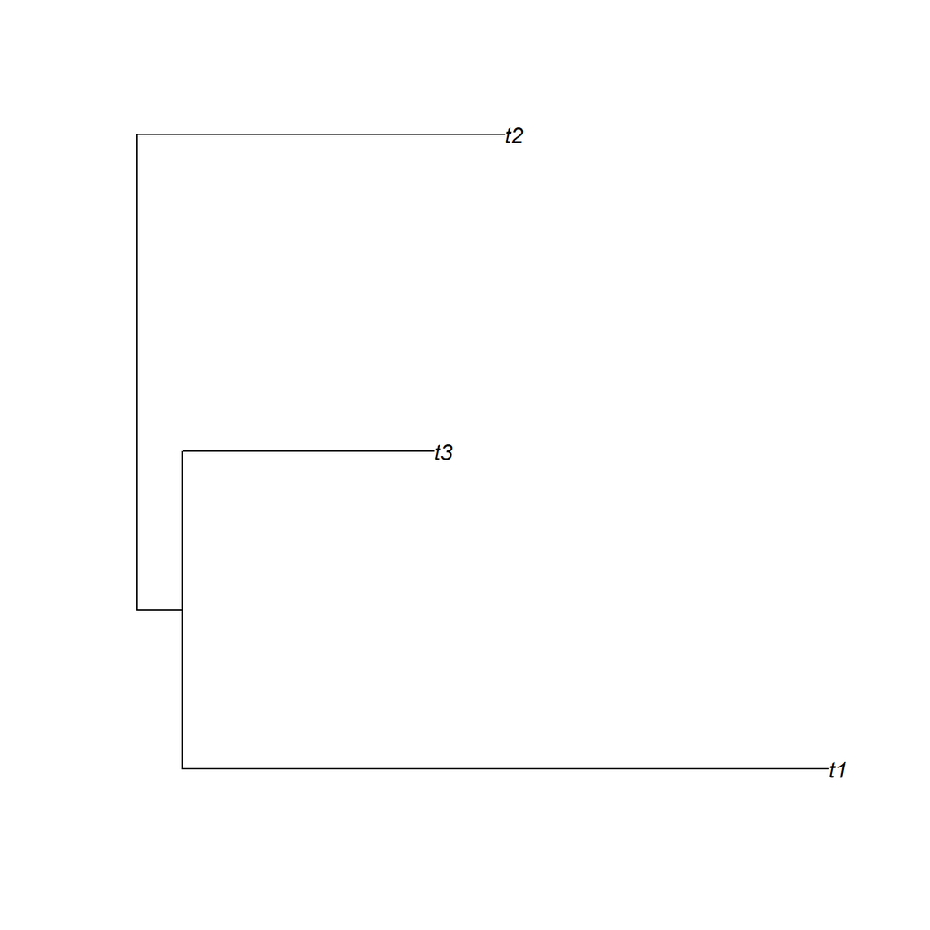

```r
library(ape)
oldtips <- c("t2", "t1", "t3")
oldtree <- rtree(n = 3, tip.label = oldtips)
plot(oldtree)
```

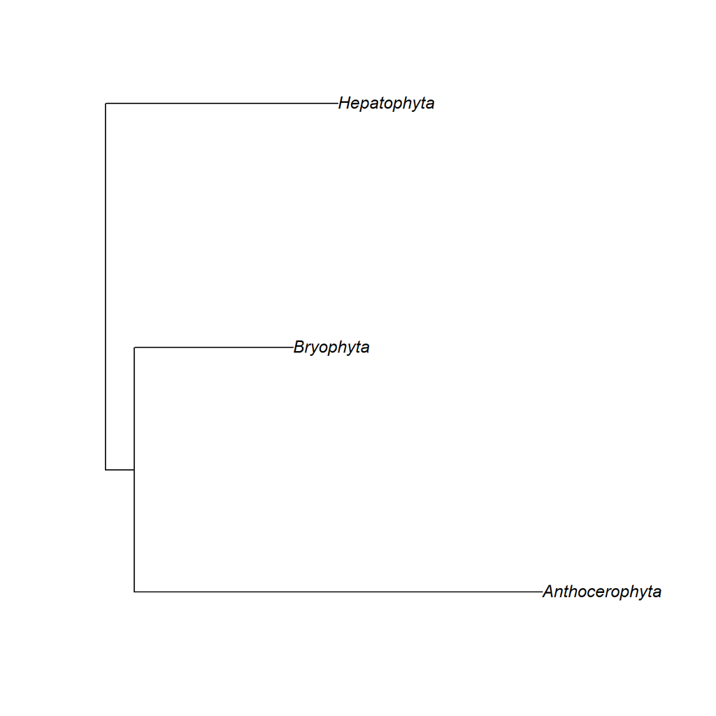

```r
new_tiplabels <- c("Anthocerophyta", "Bryophyta", "Hepatophyta")
oldtree$tip.label <- new_tiplabels
plot(oldtree)
```

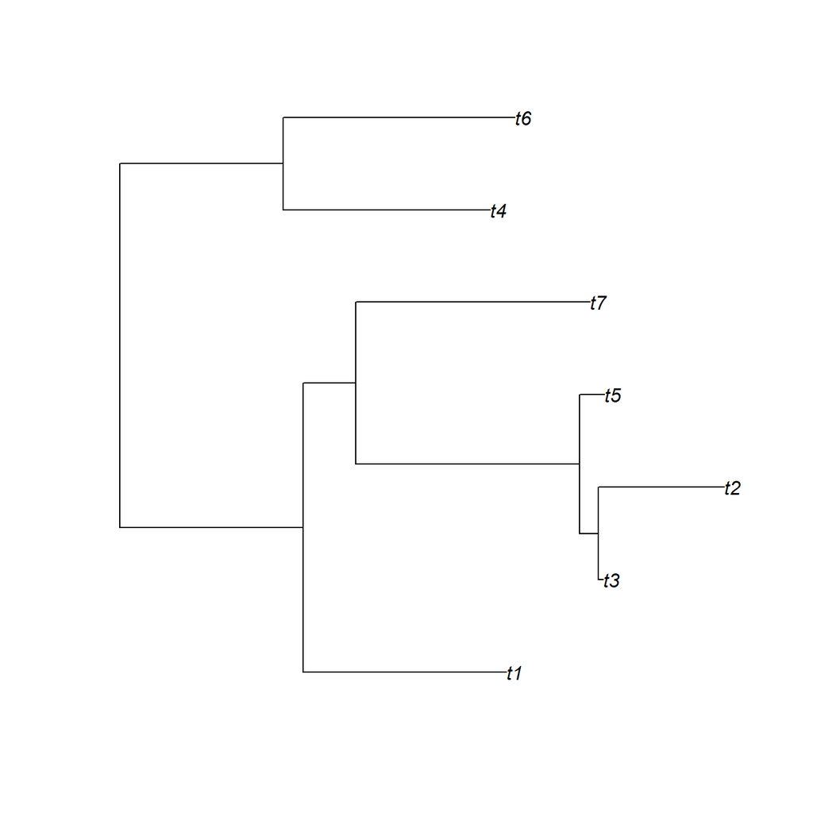

```r
library(ape)
labelstip <- c("t1", "t2", "t3", "t4", "t5", "t6", "t7")
firstt <- rtree(n = 7, tip.label = labelstip)
plot(firstt)
```

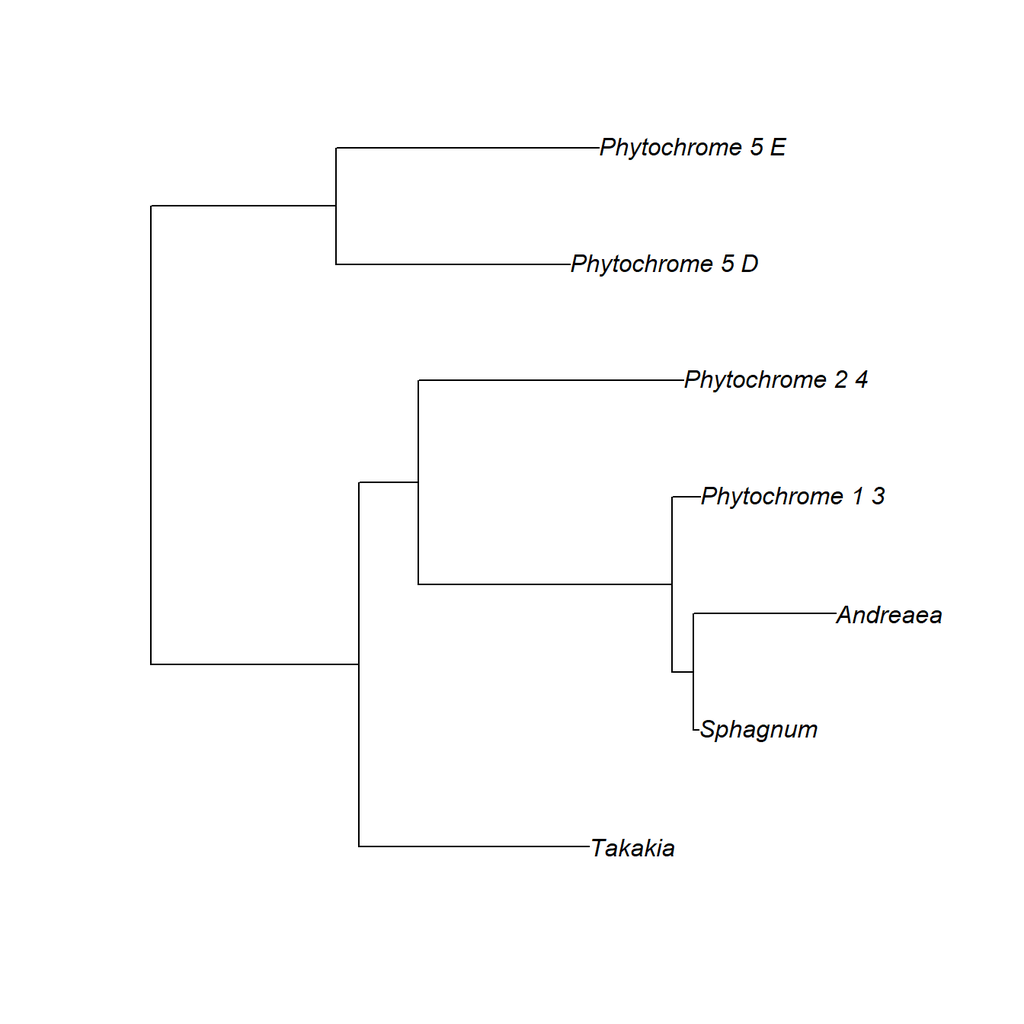

```r
brandnew <- c("Takakia", "Sphagnum", "Andreaea",  "Phytochrome 1_3", "Phytochrome 2_4", "Phytochrome 5_D", "Phytochrome 5_E")
firstt$tip.label <- brandnew
plot(firstt)
```